# assignment_7_hhq

Assignment 7.

## Hassaan Ul Haq

```python
spark.version
```

```
'3.5.1'
```

```python
import time
import pandas as pd
from itertools import islice
from google.cloud import storage
```

```python
def list_blobs(bucket_name, folder_name):
    """List all files in given COS directory."""
    gcs_client = storage.Client()
    bucket = gcs_client.bucket(bucket_name)
    blobs = list(bucket.list_blobs(prefix=folder_name))
    for blob in blobs:
        print(blob.name + '\t' + str(blob.size))
```

```python
def upload_blob(bucket_name, source_file_name, destination_blob_name):
    """Uploads a file to the bucket."""
    gcs_client = storage.Client()
    bucket = gcs_client.bucket(bucket_name)
    blob = bucket.blob(destination_blob_name)
    blob.upload_from_filename(source_file_name)
```

```python
def download_blob(bucket_name, source_blob_name, destination_file_name):
    """Downloads a blob from COS bucket."""
    gcs_client = storage.Client()
    bucket = gcs_client.bucket(bucket_name)
    blob = bucket.blob(source_blob_name)
    blob.download_to_filename(destination_file_name)
```

```python
def delete_folder(bucket_name, folder_name):
    """Delete folder from COS bucket."""
    gcs_client = storage.Client()
    bucket = gcs_client.bucket(bucket_name)
    blobs = list(bucket.list_blobs(prefix=folder_name))
    for blob in blobs:
        blob.delete()
```

```python
def list_blobs_pd(bucket_name, folder_name):
    """List all files in given COS directory."""
    gcs_client = storage.Client()
    bucket = gcs_client.bucket(bucket_name)
    blobs = list(bucket.list_blobs(prefix=folder_name))

    blob_name = []
    blob_size = []

    for blob in blobs:
        blob_name.append(blob.name)
        blob_size.append(blob.size)

    blobs_df = pd.DataFrame(list(zip(blob_name, blob_size)), columns=['Name','Size'])

    blobs_df = blobs_df.style.format({"Size": "{:,.0f}"})

    return blobs_df
```

```python
bucket_read = 'msca-bdp-amazon'

bucket_write = 'msca-bdp-students-bucket'
output_prefix = 'hhaq'
```

## Reading Data into the file

```python
%%time

!hadoop fs -ls "gs://msca-bdp-amazon/amazon_reviews/"
```

```
/usr/bin/sh: 1: hadoop: not found
CPU times: user 11.6 ms, sys: 7.84 ms, total: 19.4 ms
Wall time: 191 ms
```

```python
list_blobs(bucket_read, 'amazon_reviews/')
```

```
amazon_reviews/	0
amazon_reviews/amazon_reviews_us_Apparel_v1_00.tsv	1971061630
amazon_reviews/amazon_reviews_us_Automotive_v1_00.tsv	1350294084
amazon_reviews/amazon_reviews_us_Baby_v1_00.tsv	872274720
amazon_reviews/amazon_reviews_us_Beauty_v1_00.tsv	2152186111
amazon_reviews/amazon_reviews_us_Books_v1_00.tsv	6699171766
amazon_reviews/amazon_reviews_us_Books_v1_01.tsv	6703921864
amazon_reviews/amazon_reviews_us_Books_v1_02.tsv	3238702530
amazon_reviews/amazon_reviews_us_Camera_v1_00.tsv	1100169988
amazon_reviews/amazon_reviews_us_Digital_Ebook_Purchase_v1_00.tsv	6696964946
amazon_reviews/amazon_reviews_us_Digital_Ebook_Purchase_v1_01.tsv	3224038446
amazon_reviews/amazon_reviews_us_Digital_Music_Purchase_v1_00.tsv	628880453
amazon_reviews/amazon_reviews_us_Digital_Software_v1_00.tsv	53855391
amazon_reviews/amazon_reviews_us_Digital_Video_Download_v1_00.tsv	1288048833
amazon_reviews/amazon_reviews_us_Digital_Video_Games_v1_00.tsv	73154460
amazon_reviews/amazon_reviews_us_Electronics_v1_00.tsv	1725988504
amazon_reviews/amazon_reviews_us_Furniture_v1_00.tsv	366979553
amazon_reviews/amazon_reviews_us_Gift_Card_v1_00.tsv	39977611
amazon_reviews/amazon_reviews_us_Grocery_v1_00.tsv	956224754
amazon_reviews/amazon_reviews_us_Health_Personal_Care_v1_00.tsv	2422088742
amazon_reviews/amazon_reviews_us_Home_Entertainment_v1_00.tsv	500303241
amazon_reviews/amazon_reviews_us_Home_Improvement_v1_00.tsv	1202422006
amazon_reviews/amazon_reviews_us_Home_v1_00.tsv	2496148207
amazon_reviews/amazon_reviews_us_Jewelry_v1_00.tsv	617809191
amazon_reviews/amazon_reviews_us_Kitchen_v1_00.tsv	2218102275
amazon_reviews/amazon_reviews_us_Lawn_and_Garden_v1_00.tsv	1148784380
amazon_reviews/amazon_reviews_us_Luggage_v1_00.tsv	150519467
amazon_reviews/amazon_reviews_us_Major_Appliances_v1_00.tsv	62977388
amazon_reviews/amazon_reviews_us_Mobile_Apps_v1_00.tsv	1384889812
amazon_reviews/amazon_reviews_us_Mobile_Electronics_v1_00.tsv	58221236
amazon_reviews/amazon_reviews_us_Music_v1_00.tsv	3671037159
amazon_reviews/amazon_reviews_us_Musical_Instruments_v1_00.tsv	475220114
amazon_reviews/amazon_reviews_us_Office_Products_v1_00.tsv	1243069057
amazon_reviews/amazon_reviews_us_Outdoors_v1_00.tsv	1061801717
amazon_reviews/amazon_reviews_us_PC_v1_00.tsv	3648888910
amazon_reviews/amazon_reviews_us_Personal_Care_Appliances_v1_00.tsv	44891575
amazon_reviews/amazon_reviews_us_Pet_Products_v1_00.tsv	1227951681
amazon_reviews/amazon_reviews_us_Shoes_v1_00.tsv	1570176560
amazon_reviews/amazon_reviews_us_Software_v1_00.tsv	249565371
amazon_reviews/amazon_reviews_us_Sports_v1_00.tsv	2007024927
amazon_reviews/amazon_reviews_us_Tools_v1_00.tsv	788203941
amazon_reviews/amazon_reviews_us_Toys_v1_00.tsv	1962834272
amazon_reviews/amazon_reviews_us_Video_DVD_v1_00.tsv	3708889477
amazon_reviews/amazon_reviews_us_Video_Games_v1_00.tsv	1204902329
amazon_reviews/amazon_reviews_us_Video_v1_00.tsv	337970606
amazon_reviews/amazon_reviews_us_Watches_v1_00.tsv	412542975
amazon_reviews/amazon_reviews_us_Wireless_v1_00.tsv	4198056580
```

```python
list_blobs_pd(bucket_read, 'amazon_reviews/')
```

|  | Name | Size |
| --- | --- | --- |
| 0 | amazon_reviews/ | 0 |
| 1 | amazon_reviews/amazon_reviews_us_Apparel_v1_00.tsv | 1,971,061,630 |
| 2 | amazon_reviews/amazon_reviews_us_Automotive_v1_00.tsv | 1,350,294,084 |
| 3 | amazon_reviews/amazon_reviews_us_Baby_v1_00.tsv | 872,274,720 |
| 4 | amazon_reviews/amazon_reviews_us_Beauty_v1_00.tsv | 2,152,186,111 |
| 5 | amazon_reviews/amazon_reviews_us_Books_v1_00.tsv | 6,699,171,766 |
| 6 | amazon_reviews/amazon_reviews_us_Books_v1_01.tsv | 6,703,921,864 |
| 7 | amazon_reviews/amazon_reviews_us_Books_v1_02.tsv | 3,238,702,530 |
| 8 | amazon_reviews/amazon_reviews_us_Camera_v1_00.tsv | 1,100,169,988 |
| 9 | amazon_reviews/amazon_reviews_us_Digital_Ebook_Purchase_v1_00.tsv | 6,696,964,946 |
| 10 | amazon_reviews/amazon_reviews_us_Digital_Ebook_Purchase_v1_01.tsv | 3,224,038,446 |
| 11 | amazon_reviews/amazon_reviews_us_Digital_Music_Purchase_v1_00.tsv | 628,880,453 |
| 12 | amazon_reviews/amazon_reviews_us_Digital_Software_v1_00.tsv | 53,855,391 |
| 13 | amazon_reviews/amazon_reviews_us_Digital_Video_Download_v1_00.tsv | 1,288,048,833 |
| 14 | amazon_reviews/amazon_reviews_us_Digital_Video_Games_v1_00.tsv | 73,154,460 |
| 15 | amazon_reviews/amazon_reviews_us_Electronics_v1_00.tsv | 1,725,988,504 |
| 16 | amazon_reviews/amazon_reviews_us_Furniture_v1_00.tsv | 366,979,553 |
| 17 | amazon_reviews/amazon_reviews_us_Gift_Card_v1_00.tsv | 39,977,611 |
| 18 | amazon_reviews/amazon_reviews_us_Grocery_v1_00.tsv | 956,224,754 |
| 19 | amazon_reviews/amazon_reviews_us_Health_Personal_Care_v1_00.tsv | 2,422,088,742 |
| 20 | amazon_reviews/amazon_reviews_us_Home_Entertainment_v1_00.tsv | 500,303,241 |
| 21 | amazon_reviews/amazon_reviews_us_Home_Improvement_v1_00.tsv | 1,202,422,006 |
| 22 | amazon_reviews/amazon_reviews_us_Home_v1_00.tsv | 2,496,148,207 |
| 23 | amazon_reviews/amazon_reviews_us_Jewelry_v1_00.tsv | 617,809,191 |
| 24 | amazon_reviews/amazon_reviews_us_Kitchen_v1_00.tsv | 2,218,102,275 |
| 25 | amazon_reviews/amazon_reviews_us_Lawn_and_Garden_v1_00.tsv | 1,148,784,380 |
| 26 | amazon_reviews/amazon_reviews_us_Luggage_v1_00.tsv | 150,519,467 |
| 27 | amazon_reviews/amazon_reviews_us_Major_Appliances_v1_00.tsv | 62,977,388 |
| 28 | amazon_reviews/amazon_reviews_us_Mobile_Apps_v1_00.tsv | 1,384,889,812 |
| 29 | amazon_reviews/amazon_reviews_us_Mobile_Electronics_v1_00.tsv | 58,221,236 |
| 30 | amazon_reviews/amazon_reviews_us_Music_v1_00.tsv | 3,671,037,159 |
| 31 | amazon_reviews/amazon_reviews_us_Musical_Instruments_v1_00.tsv | 475,220,114 |
| 32 | amazon_reviews/amazon_reviews_us_Office_Products_v1_00.tsv | 1,243,069,057 |
| 33 | amazon_reviews/amazon_reviews_us_Outdoors_v1_00.tsv | 1,061,801,717 |
| 34 | amazon_reviews/amazon_reviews_us_PC_v1_00.tsv | 3,648,888,910 |
| 35 | amazon_reviews/amazon_reviews_us_Personal_Care_Appliances_v1_00.tsv | 44,891,575 |
| 36 | amazon_reviews/amazon_reviews_us_Pet_Products_v1_00.tsv | 1,227,951,681 |
| 37 | amazon_reviews/amazon_reviews_us_Shoes_v1_00.tsv | 1,570,176,560 |
| 38 | amazon_reviews/amazon_reviews_us_Software_v1_00.tsv | 249,565,371 |
| 39 | amazon_reviews/amazon_reviews_us_Sports_v1_00.tsv | 2,007,024,927 |
| 40 | amazon_reviews/amazon_reviews_us_Tools_v1_00.tsv | 788,203,941 |
| 41 | amazon_reviews/amazon_reviews_us_Toys_v1_00.tsv | 1,962,834,272 |
| 42 | amazon_reviews/amazon_reviews_us_Video_DVD_v1_00.tsv | 3,708,889,477 |
| 43 | amazon_reviews/amazon_reviews_us_Video_Games_v1_00.tsv | 1,204,902,329 |
| 44 | amazon_reviews/amazon_reviews_us_Video_v1_00.tsv | 337,970,606 |
| 45 | amazon_reviews/amazon_reviews_us_Watches_v1_00.tsv | 412,542,975 |
| 46 | amazon_reviews/amazon_reviews_us_Wireless_v1_00.tsv | 4,198,056,580 |

```python
list_blobs(bucket_read, '/')
```

## Q1 Which product category gets most reviews

```python
readme_raw = sc.textFile("gs://msca-bdp-data-open/airlines/2007.csv")
readme = readme_raw.mapPartitionsWithIndex(lambda i, iter: islice(iter, 1, None) if i == 0 else iter) #filter out header
readme.count()
```

```
7453215
```

```python
readme_cos = sc.textFile("gs://msca-bdp-amazon/amazon_reviews/*.tsv")

header = readme_cos.first()  # Get header row
review_lines = readme_cos.filter(lambda line: line != header)  # Remove header
print(review_lines.count())  # Count only review rows
```

```
[Stage 1:====================================================>(1197 + 1) / 1198]
```

```
150962278
```

```python
type(readme_cos)
```

```
pyspark.rdd.RDD
```

```python
readme_cos.take(1)
```

```
['marketplace\tcustomer_id\treview_id\tproduct_id\tproduct_parent\tproduct_title\tproduct_category\tstar_rating\thelpful_votes\ttotal_votes\tvine\tverified_purchase\treview_headline\treview_body\treview_date']
```

### 6 is category and 7 is star rating

```python
category_rdd = review_lines.map(lambda line: line.split("\t")[5])

category_counts = category_rdd.map(lambda category: (category, 1)).reduceByKey(lambda a, b: a + b)

most_reviewed_category = category_counts.max(key=lambda x: x[1])

print(f"Category with highest reviews: {most_reviewed_category[0]} ({most_reviewed_category[1]} reviews)")
```

```
[Stage 4:===================================================>(1184 + 14) / 1198]
```

[output not shown]

```python
least_reviewed_category=category_counts.min(key=lambda x: x[1])
print(f"Category with lowest reviews: {least_reviewed_category[0]} ({least_reviewed_category[1]} reviews)")
```

```
[Stage 8:===================================================>(1185 + 13) / 1198]
```

[output not shown]

## Q2 lowest/highest star rating

```python
mapped_rdd = review_lines.map(lambda line: line.split('\t'))
category_rating_rdd = mapped_rdd.map(lambda fields: (fields[6], float(fields[7])))
```

```python
category_agg_rdd = category_rating_rdd.aggregateByKey(
    (0.0, 0),
    lambda acc, value: (acc[0] + value, acc[1] + 1),  # (sum, count) accumulation
    lambda acc1, acc2: (acc1[0] + acc2[0], acc1[1] + acc2[1])  # (sum, count) merging
)
```

```python
average_ratings_rdd = category_agg_rdd.mapValues(lambda x: x[0] / x[1])

highest_rated = average_ratings_rdd.max(lambda x: x[1])

lowest_rated = average_ratings_rdd.min(lambda x: x[1])

print("Highest Rated Category:", highest_rated)
print("Lowest Rated Category:", lowest_rated)
```

```
[Stage 14:==========================================>        (1008 + 83) / 1198]
```

```
Highest Rated Category: ('Gift Card', 4.731363105858364)
Lowest Rated Category: ('Digital_Software', 3.5393303553935973)
```

## Q3

## Do you see seasonality in reviews?

## converting to df of 1000 values as i think that will be benificial here for graphs, and will save on the compute power.

## Since we need inference which is good as long as data is representative, we will random sample, and use that for the rest of the assignment

```python
sample_rdd = review_lines.takeSample(False, 1000)
```

```python
import pandas as pd

sample_list = [line.split('\t') for line in sample_rdd]

columns = ['marketplace', 'customer_id', 'review_id', 'product_id', 'product_parent',
           'product_title', 'product_category', 'star_rating', 'helpful_votes',
           'total_votes', 'vine', 'verified_purchase', 'review_headline', 'review_body',
           'review_date']

df = pd.DataFrame(sample_list, columns=columns)

df['review_date'] = pd.to_datetime(df['review_date'])
```

```python
df.head()
```

[output not shown]

```python
df['year']=df['review_date'].dt.year
df['month']=df['review_date'].dt.month
```

[figure not shown]

```python
monthly_reviews = df.groupby('month').size().reset_index(name='review_count')
import matplotlib.pyplot as plt

# Plotting the seasonality
plt.figure(figsize=(10,6))
monthly_reviews['month_year'] = monthly_reviews['year'].astype(str) + '-' + monthly_reviews['month'].astype(str)
plt.plot(monthly_reviews['month_year'], monthly_reviews['review_count'], marker='o')
plt.xticks(rotation=90)
plt.title('Review Count by Month-Year')
plt.xlabel('Month-Year')
plt.ylabel('Number of Reviews')
plt.tight_layout()
plt.show()
```

[figure not shown]

```python
# since above graph is useless, i will use quarterly months, Jan, April, July, October for data
plt.figure(figsize=(10,6))
plt.plot(monthly_reviews['year'] + (monthly_reviews['month'] - 1) / 12, monthly_reviews['review_count'], marker='o', linestyle='-', color='b', alpha=0.5)

# Set plot title and labels
plt.title('Review Count by Year and Month (Seasonality)')
plt.xlabel('Year')
plt.ylabel('Number of Reviews')

# Set x-ticks to show only January, April, July, October for each year
quarters = monthly_reviews[(monthly_reviews['month'] == 1) | (monthly_reviews['month'] == 4) |
                           (monthly_reviews['month'] == 7) | (monthly_reviews['month'] == 10)]
x_ticks = quarters['year'] + (quarters['month'] - 1) / 12
plt.xticks(x_ticks, [f'{int(year)}-{str(month).zfill(2)}' for year, month in zip(quarters['year'], quarters['month'])], rotation=90)

# Display the plot
plt.tight_layout()
plt.show()
```

### Doesn't seem to have seasonality

### 3.1 Is every product category getting consistent number of reviews throughout the year?

```python
df.head()
```

|  | marketplace | customer_id | review_id | product_id | product_parent | product_title | product_category | star_rating | helpful_votes | total_votes | vine | verified_purchase | review_headline | review_body | review_date | year | month |
| --- | --- | --- | --- | --- | --- | --- | --- | --- | --- | --- | --- | --- | --- | --- | --- | --- | --- |
| 0 | US | 10396970 | R1A95MEK8H1QDL | B00CKW6FVE | 525332519 | TETRIS® Blitz | Mobile_Apps | 5 | 0 | 0 | N | Y | great game | This game is a must have game .Keeps your mind... | 2014-06-14 | 2014 | 6 |
| 1 | US | 24419342 | R1ZZ8ZTRX3KCXG | B00009YXGU | 876481023 | I've Been Waiting for You | Video DVD | 4 | 1 | 1 | N | N | The plot is out there but the movie is great | The plot is way out there but the movie is gre... | 2006-03-12 | 2006 | 3 |
| 2 | US | 45391511 | R3SZOIGI99UU9C | B0000CBGBS | 893173019 | Fisher-Price Baby Papasan (Discontinued by Man... | Baby | 2 | 0 | 0 | N | N | Good for newborns... | I loved this seat the minute I saw it and rece... | 2005-11-07 | 2005 | 11 |
| 3 | US | 36325004 | RAA48I6Q9LZKF | B00OUNOG4E | 879039834 | Laggies | Digital_Video_Download | 4 | 0 | 0 | N | Y | Laggies was pretty good | I liked the movie and would recommend it. I g... | 2015-08-15 | 2015 | 8 |
| 4 | US | 52506669 | RIEZ5OAZ8ODHI | B004HGXVOK | 623155886 | Littermaid LM980 Mega Self-Cleaning Litter Box | Pet Products | 4 | 0 | 0 | N | Y | I wouldn't be without this product, but I wish... | I wouldn't be without this product, but I wish... | 2015-08-02 | 2015 | 8 |

```python
## going to use the representative data to save space on the server
df['year_month'] = df['review_date'].dt.to_period('M')
## unstacking the data will create a pivot table for time period and category, which then we can analyze
category_monthly_counts = df.groupby(['product_category', 'year_month']).size().unstack(fill_value=0)
```

```python
df.head()
```

|  | marketplace | customer_id | review_id | product_id | product_parent | product_title | product_category | star_rating | helpful_votes | total_votes | vine | verified_purchase | review_headline | review_body | review_date | year | month | year_month |
| --- | --- | --- | --- | --- | --- | --- | --- | --- | --- | --- | --- | --- | --- | --- | --- | --- | --- | --- |
| 0 | US | 10396970 | R1A95MEK8H1QDL | B00CKW6FVE | 525332519 | TETRIS® Blitz | Mobile_Apps | 5 | 0 | 0 | N | Y | great game | This game is a must have game .Keeps your mind... | 2014-06-14 | 2014 | 6 | 2014-06 |
| 1 | US | 24419342 | R1ZZ8ZTRX3KCXG | B00009YXGU | 876481023 | I've Been Waiting for You | Video DVD | 4 | 1 | 1 | N | N | The plot is out there but the movie is great | The plot is way out there but the movie is gre... | 2006-03-12 | 2006 | 3 | 2006-03 |
| 2 | US | 45391511 | R3SZOIGI99UU9C | B0000CBGBS | 893173019 | Fisher-Price Baby Papasan (Discontinued by Man... | Baby | 2 | 0 | 0 | N | N | Good for newborns... | I loved this seat the minute I saw it and rece... | 2005-11-07 | 2005 | 11 | 2005-11 |
| 3 | US | 36325004 | RAA48I6Q9LZKF | B00OUNOG4E | 879039834 | Laggies | Digital_Video_Download | 4 | 0 | 0 | N | Y | Laggies was pretty good | I liked the movie and would recommend it. I g... | 2015-08-15 | 2015 | 8 | 2015-08 |
| 4 | US | 52506669 | RIEZ5OAZ8ODHI | B004HGXVOK | 623155886 | Littermaid LM980 Mega Self-Cleaning Litter Box | Pet Products | 4 | 0 | 0 | N | Y | I wouldn't be without this product, but I wish... | I wouldn't be without this product, but I wish... | 2015-08-02 | 2015 | 8 | 2015-08 |

```python
category_monthly_counts.head()
```

| year_month product_category | 1998-04 | 1998-09 | 1998-10 | 1998-11 | 1999-09 | 1999-11 | 1999-12 | 2000-01 | 2000-02 | 2000-03 | ... | 2014-11 | 2014-12 | 2015-01 | 2015-02 | 2015-03 | 2015-04 | 2015-05 | 2015-06 | 2015-07 | 2015-08 |
| --- | --- | --- | --- | --- | --- | --- | --- | --- | --- | --- | --- | --- | --- | --- | --- | --- | --- | --- | --- | --- | --- |
| Apparel | 0 | 0 | 0 | 0 | 0 | 0 | 0 | 0 | 0 | 0 | ... | 3 | 1 | 5 | 0 | 4 | 1 | 3 | 2 | 3 | 0 |
| Automotive | 0 | 0 | 0 | 0 | 0 | 0 | 0 | 0 | 0 | 0 | ... | 0 | 0 | 1 | 1 | 0 | 0 | 1 | 0 | 0 | 2 |
| Baby | 0 | 0 | 0 | 0 | 0 | 0 | 0 | 0 | 0 | 0 | ... | 0 | 0 | 0 | 0 | 1 | 0 | 0 | 0 | 0 | 0 |
| Beauty | 0 | 0 | 0 | 0 | 0 | 0 | 0 | 0 | 0 | 0 | ... | 2 | 1 | 3 | 3 | 3 | 1 | 2 | 1 | 1 | 2 |
| Books | 1 | 0 | 1 | 1 | 1 | 1 | 1 | 1 | 1 | 1 | ... | 1 | 1 | 1 | 2 | 0 | 5 | 4 | 2 | 4 | 0 |

5 rows × 139 columns

```python
category_stats = category_monthly_counts.agg(['mean', 'std', 'min', 'max'])
print(category_stats)
```

```
year_month   1998-04   1998-09   1998-10   1998-11   1999-09   1999-11  \
mean        0.024390  0.024390  0.024390  0.024390  0.024390  0.024390
std         0.156174  0.156174  0.156174  0.156174  0.156174  0.156174
min         0.000000  0.000000  0.000000  0.000000  0.000000  0.000000
max         1.000000  1.000000  1.000000  1.000000  1.000000  1.000000

year_month   1999-12   2000-01   2000-02   2000-03  ...   2014-11   2014-12  \
mean        0.024390  0.024390  0.024390  0.024390  ...  0.658537  0.731707
std         0.156174  0.156174  0.156174  0.156174  ...  0.938343  1.025290
min         0.000000  0.000000  0.000000  0.000000  ...  0.000000  0.000000
max         1.000000  1.000000  1.000000  1.000000  ...  3.000000  4.000000

year_month   2015-01   2015-02   2015-03   2015-04   2015-05   2015-06  \
mean        1.024390  0.804878  0.853659  0.902439  1.024390  0.682927
std         1.604491  1.418089  1.314553  1.462957  1.254747  0.985876
min         0.000000  0.000000  0.000000  0.000000  0.000000  0.000000
max         7.000000  7.000000  5.000000  5.000000  5.000000  4.000000

year_month   2015-07   2015-08
mean        0.853659  0.756098
std         1.152410  1.157162
min         0.000000  0.000000
max         4.000000  6.000000

[4 rows x 139 columns]
```

```python
import numpy as np

## make a new df crouped by category and year, and then make a disaggregated pivot of it
yearly_counts = df.groupby(['product_category', 'year']).size().unstack(fill_value=0)

category_mean = yearly_counts.mean(axis=1)
category_std = yearly_counts.std(axis=1)

category_cv = category_std / category_mean

result = category_cv.sort_values(ascending=False)

print("Coefficient of Variation (CV) by Product Category:")
print(result)
```

```
Coefficient of Variation (CV) by Product Category:
product_category
Personal_Care_Appliances    4.242641
Mobile_Electronics          4.242641
Gift Card                   4.242641
Digital_Video_Games         4.242641
Luggage                     3.086975
Video                       2.910428
Software                    2.910428
Digital_Video_Download      2.782561
Apparel                     2.674084
Home Improvement            2.527059
Tools                       2.520504
Grocery                     2.467435
Home Entertainment          2.467435
Beauty                      2.467435
Furniture                   2.343640
Shoes                       2.141037
Toys                        2.078461
Health & Personal Care      2.077474
Camera                      2.073999
Video Games                 2.073999
Musical Instruments         2.057983
Office Products             2.047456
Sports                      2.043556
PC                          1.999602
Home                        1.996537
Pet Products                1.995376
Mobile_Apps                 1.962414
Digital_Ebook_Purchase      1.940500
Wireless                    1.927815
Jewelry                     1.897367
Automotive                  1.868570
Outdoors                    1.847746
Digital_Music_Purchase      1.832937
Baby                        1.794349
Kitchen                     1.722536
Electronics                 1.669585
Watches                     1.659199
Lawn and Garden             1.585782
Books                       1.135133
Music                       0.965392
Video DVD                   0.953014
dtype: float64
```

#### Video DVD and Music have the lowest coeffecient of variance, however even they are variating throughout the year

### 3.2 Any product categories that are getting more reviews during certain times of the year? If yes, which product categories and what times of the year?

#### with the work done in prev question, we know that Personal_Care_Appliances; Mobile_Electronics; Gift Card; and Digital_Video_Games have the highest cv of 4.242641. Let's find their months

```python
monthly_counts = df.groupby(['product_category', 'month']).size().unstack(fill_value=0)
```

```python
monthly_avg = monthly_counts.mean()
```

```python
category_totals = monthly_counts.sum(axis=1).sort_values(ascending=False)
```

```python
## here we will use category_cv we used in the last question. This will save compute power and make code effecient too
```

```python
type(category_cv)
```

```
pandas.core.series.Series
```

```python
top_6_cv_categories = category_cv.nlargest(6).index

# Print the top 6 categories and their CV values
print("Top 6 categories by Coefficient of Variation:")
for category in top_6_cv_categories:
    print(f"{category}: {category_cv[category]:.2f}")
```

```
Top 6 categories by Coefficient of Variation:
Digital_Video_Games: 4.24
Gift Card: 4.24
Mobile_Electronics: 4.24
Personal_Care_Appliances: 4.24
Luggage: 3.09
Video: 2.91
```

```python
# peak month for these top 6
peak_months_top6 = monthly_counts.loc[top_6_cv_categories].idxmax(axis=1)

print("\nPeak months for top 6 categories with highest CV:")
for category, peak_month in peak_months_top6.items():
    print(f"{category}: Month {peak_month}")
```

```
Peak months for top 6 categories with highest CV:
Digital_Video_Games: Month 7
Gift Card: Month 12
Mobile_Electronics: Month 6
Personal_Care_Appliances: Month 8
Luggage: Month 5
Video: Month 5
```

## for the entire dataset

```python
monthly_avg = monthly_counts.mean(axis=1).sort_values(ascending=False)

peak_months = monthly_counts.idxmax(axis=1)
print("\nPeak months for each category:")
print(peak_months)
```

```
Peak months for each category:
product_category
Apparel                      3
Automotive                   5
Baby                         3
Beauty                       6
Books                       10
Camera                       5
Digital_Ebook_Purchase       8
Digital_Music_Purchase       1
Digital_Video_Download       7
Digital_Video_Games          7
Electronics                  1
Furniture                    1
Gift Card                   12
Grocery                      7
Health & Personal Care       4
Home                        12
Home Entertainment          12
Home Improvement             3
Jewelry                      1
Kitchen                      5
Lawn and Garden              2
Luggage                      5
Mobile_Apps                  1
Mobile_Electronics           6
Music                        1
Musical Instruments          1
Office Products             12
Outdoors                     5
PC                           1
Personal_Care_Appliances     8
Pet Products                 4
Shoes                        7
Software                     5
Sports                       3
Tools                        1
Toys                        12
Video                        5
Video DVD                    8
Video Games                 11
Watches                      5
Wireless                     1
dtype: int32
```

## Q4

Which reviews are getting the most helpful votes / total votes?

```python
df.head()
```

|  | marketplace | customer_id | review_id | product_id | product_parent | product_title | product_category | star_rating | helpful_votes | total_votes | vine | verified_purchase | review_headline | review_body | review_date | year | month | year_month |
| --- | --- | --- | --- | --- | --- | --- | --- | --- | --- | --- | --- | --- | --- | --- | --- | --- | --- | --- |
| 0 | US | 10396970 | R1A95MEK8H1QDL | B00CKW6FVE | 525332519 | TETRIS® Blitz | Mobile_Apps | 5 | 0 | 0 | N | Y | great game | This game is a must have game .Keeps your mind... | 2014-06-14 | 2014 | 6 | 2014-06 |
| 1 | US | 24419342 | R1ZZ8ZTRX3KCXG | B00009YXGU | 876481023 | I've Been Waiting for You | Video DVD | 4 | 1 | 1 | N | N | The plot is out there but the movie is great | The plot is way out there but the movie is gre... | 2006-03-12 | 2006 | 3 | 2006-03 |
| 2 | US | 45391511 | R3SZOIGI99UU9C | B0000CBGBS | 893173019 | Fisher-Price Baby Papasan (Discontinued by Man... | Baby | 2 | 0 | 0 | N | N | Good for newborns... | I loved this seat the minute I saw it and rece... | 2005-11-07 | 2005 | 11 | 2005-11 |
| 3 | US | 36325004 | RAA48I6Q9LZKF | B00OUNOG4E | 879039834 | Laggies | Digital_Video_Download | 4 | 0 | 0 | N | Y | Laggies was pretty good | I liked the movie and would recommend it. I g... | 2015-08-15 | 2015 | 8 | 2015-08 |
| 4 | US | 52506669 | RIEZ5OAZ8ODHI | B004HGXVOK | 623155886 | Littermaid LM980 Mega Self-Cleaning Litter Box | Pet Products | 4 | 0 | 0 | N | Y | I wouldn't be without this product, but I wish... | I wouldn't be without this product, but I wish... | 2015-08-02 | 2015 | 8 | 2015-08 |

Which reviews are getting the most helpful votes / total votes?

```python
df['total_votes'] = pd.to_numeric(df['total_votes'])
df['helpful_votes'] = pd.to_numeric(df['helpful_votes'])
```

```python
df['helpful_ratio']=df['helpful_votes']/df['total_votes']
```

```python
df.head()
```

|  | marketplace | customer_id | review_id | product_id | product_parent | product_title | product_category | star_rating | helpful_votes | total_votes | vine | verified_purchase | review_headline | review_body | review_date | year | month | year_month | helpful_ratio |
| --- | --- | --- | --- | --- | --- | --- | --- | --- | --- | --- | --- | --- | --- | --- | --- | --- | --- | --- | --- |
| 0 | US | 10396970 | R1A95MEK8H1QDL | B00CKW6FVE | 525332519 | TETRIS® Blitz | Mobile_Apps | 5 | 0 | 0 | N | Y | great game | This game is a must have game .Keeps your mind... | 2014-06-14 | 2014 | 6 | 2014-06 | NaN |
| 1 | US | 24419342 | R1ZZ8ZTRX3KCXG | B00009YXGU | 876481023 | I've Been Waiting for You | Video DVD | 4 | 1 | 1 | N | N | The plot is out there but the movie is great | The plot is way out there but the movie is gre... | 2006-03-12 | 2006 | 3 | 2006-03 | 1.0 |
| 2 | US | 45391511 | R3SZOIGI99UU9C | B0000CBGBS | 893173019 | Fisher-Price Baby Papasan (Discontinued by Man... | Baby | 2 | 0 | 0 | N | N | Good for newborns... | I loved this seat the minute I saw it and rece... | 2005-11-07 | 2005 | 11 | 2005-11 | NaN |
| 3 | US | 36325004 | RAA48I6Q9LZKF | B00OUNOG4E | 879039834 | Laggies | Digital_Video_Download | 4 | 0 | 0 | N | Y | Laggies was pretty good | I liked the movie and would recommend it. I g... | 2015-08-15 | 2015 | 8 | 2015-08 | NaN |
| 4 | US | 52506669 | RIEZ5OAZ8ODHI | B004HGXVOK | 623155886 | Littermaid LM980 Mega Self-Cleaning Litter Box | Pet Products | 4 | 0 | 0 | N | Y | I wouldn't be without this product, but I wish... | I wouldn't be without this product, but I wish... | 2015-08-02 | 2015 | 8 | 2015-08 | NaN |

```python
df_filtered = df[df['total_votes'] > 0].copy()

df_sorted = df_filtered.sort_values('helpful_ratio', ascending=False)
```

```python
print("Top 10 Most Helpful Reviews:")
print(df_sorted[['product_category', 'star_rating', 'helpful_votes', 'total_votes', 'helpful_ratio']].head(10))
```

```
Top 10 Most Helpful Reviews:
           product_category star_rating  helpful_votes  total_votes  \
1                 Video DVD           4              1            1
572  Health & Personal Care           5              1            1
567        Home Improvement           5              2            2
562                Outdoors           5              1            1
561             Mobile_Apps           5              1            1
557                   Shoes           5              2            2
555  Digital_Ebook_Purchase           5              1            1
553  Digital_Ebook_Purchase           5              1            1
552                   Books           4              1            1
539                   Tools           5              3            3

     helpful_ratio
1              1.0
572            1.0
567            1.0
562            1.0
561            1.0
557            1.0
555            1.0
553            1.0
552            1.0
539            1.0
```

### 4.1 Any correlation between the length of review headline / review body (in number words) and the "helpfulness" of the review?

```python
# I am only going to use the df filtered because i don't think there is any relationship where helpfulness ==0
df_filtered['review_body_length'] = df_filtered['review_body'].str.len()
df_filtered['review_headline_length'] = df_filtered['review_headline'].str.len()
```

```python
df_filtered.head()
```

|  | marketplace | customer_id | review_id | product_id | product_parent | product_title | product_category | star_rating | helpful_votes | total_votes | ... | verified_purchase | review_headline | review_body | review_date | year | month | year_month | helpful_ratio | review_body_length | review_headline_length |
| --- | --- | --- | --- | --- | --- | --- | --- | --- | --- | --- | --- | --- | --- | --- | --- | --- | --- | --- | --- | --- | --- |
| 1 | US | 24419342 | R1ZZ8ZTRX3KCXG | B00009YXGU | 876481023 | I've Been Waiting for You | Video DVD | 4 | 1 | 1 | ... | N | The plot is out there but the movie is great | The plot is way out there but the movie is gre... | 2006-03-12 | 2006 | 3 | 2006-03 | 1.0 | 255 | 44 |
| 5 | US | 23933208 | R2ZT5JB6L3C9EO | B0035WTVZA | 837787415 | Fujifilm FinePix HS10 10 MP CMOS Digital Camer... | Camera | 5 | 2 | 2 | ... | Y | Great bridge camera for amatuers | I spent the past week and half looking at many... | 2010-10-10 | 2010 | 10 | 2010-10 | 1.0 | 1561 | 32 |
| 6 | US | 5135182 | R1FLPN1NO8LAJD | B00K3IQCQK | 577894946 | Blissful Surrender | Digital_Ebook_Purchase | 4 | 1 | 1 | ... | Y | Sean is so freakin yummy! | I really enjoyed Sean and Sams story. I liked ... | 2015-01-11 | 2015 | 1 | 2015-01 | 1.0 | 381 | 25 |
| 13 | US | 53002787 | R1G77SWBC6NX6N | B00Q5JDH7I | 697714158 | Operation Zulu : Dead Island | Digital_Ebook_Purchase | 4 | 2 | 2 | ... | N | non stop action | Good read! Looking forward to the authors next... | 2014-12-17 | 2014 | 12 | 2014-12 | 1.0 | 124 | 15 |
| 14 | US | 23659320 | RWMN1VDW2FLSA | 0345484207 | 927617988 | The Measure of the Magic: Legends of Shannara ... | Books | 3 | 0 | 1 | ... | N | my least favorite Brooks' book; reads a bit li... | I have been a fan of Terry Brooks' books for y... | 2013-01-25 | 2013 | 1 | 2013-01 | 0.0 | 958 | 61 |

5 rows × 21 columns

```python
import seaborn as sns
```

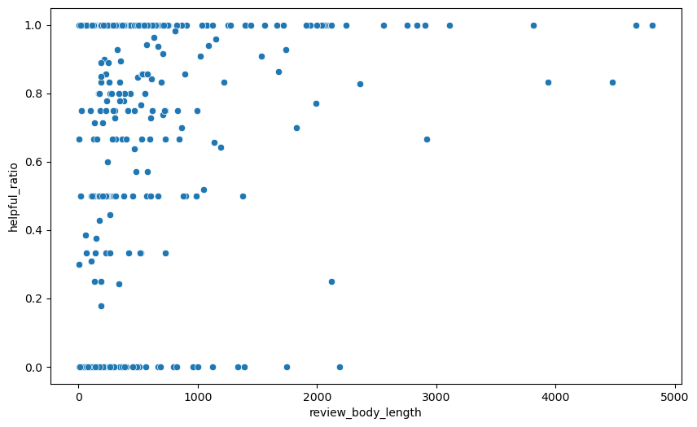

```python
plt.figure(figsize=(10, 6))
sns.scatterplot(x='review_body_length', y='helpful_ratio', data=df_filtered)
```

```python
body_correlation = df_filtered['review_body_length'].corr(df_filtered['helpful_ratio'])
print(f"\nCorrelation between helpful_ratio and review body length is: {body_correlation:.2f}")
```

```
Correlation between helpful_ratio and review body length is: 0.16
```

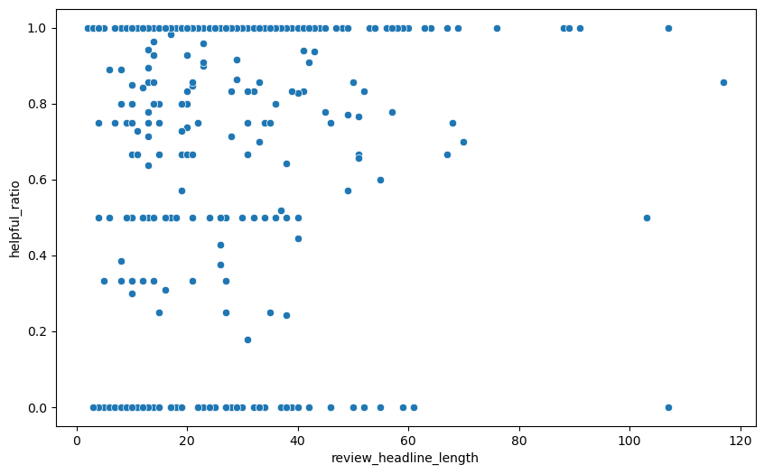

```python
plt.figure(figsize=(10, 6))
sns.scatterplot(x='review_headline_length', y='helpful_ratio', data=df_filtered)
```

```python
headline_correlation = df_filtered['review_headline_length'].corr(df_filtered['helpful_ratio'])
print(f"\nCorrelation between helpful_ratio and review headline length is: {headline_correlation:.2f}")
```

```
Correlation between helpful_ratio and review headline length is: 0.08
```

#### from the above graphs There seems to be no correlation in either review_headline_length or review_body_length with helpful ratio. It is shown by calculations too with corr of 0.16 and 0.08 respectively

### 4.2 Do you see any correlation between how many reviews a certain customer (customer_id) published and the "helpfulness" of the reviews?

```python
reviews_per_customer = df_filtered['customer_id'].value_counts().reset_index()
```

```python
reviews_per_customer.columns = ['customer_id', 'num_reviews']
```

```python
reviews_per_customer.head()
```

|  | customer_id | num_reviews |
| --- | --- | --- |
| 0 | 24419342 | 1 |
| 1 | 33454097 | 1 |
| 2 | 34575674 | 1 |
| 3 | 50740649 | 1 |
| 4 | 11546767 | 1 |

```python
customer_id_helpful=pd.merge(df_filtered, reviews_per_customer, on='customer_id', how='left')
```

```python
customer_id_helpful.head()
```

|  | marketplace | customer_id | review_id | product_id | product_parent | product_title | product_category | star_rating | helpful_votes | total_votes | ... | review_headline | review_body | review_date | year | month | year_month | helpful_ratio | review_body_length | review_headline_length | num_reviews |
| --- | --- | --- | --- | --- | --- | --- | --- | --- | --- | --- | --- | --- | --- | --- | --- | --- | --- | --- | --- | --- | --- |
| 0 | US | 24419342 | R1ZZ8ZTRX3KCXG | B00009YXGU | 876481023 | I've Been Waiting for You | Video DVD | 4 | 1 | 1 | ... | The plot is out there but the movie is great | The plot is way out there but the movie is gre... | 2006-03-12 | 2006 | 3 | 2006-03 | 1.0 | 255 | 44 | 1 |
| 1 | US | 23933208 | R2ZT5JB6L3C9EO | B0035WTVZA | 837787415 | Fujifilm FinePix HS10 10 MP CMOS Digital Camer... | Camera | 5 | 2 | 2 | ... | Great bridge camera for amatuers | I spent the past week and half looking at many... | 2010-10-10 | 2010 | 10 | 2010-10 | 1.0 | 1561 | 32 | 1 |
| 2 | US | 5135182 | R1FLPN1NO8LAJD | B00K3IQCQK | 577894946 | Blissful Surrender | Digital_Ebook_Purchase | 4 | 1 | 1 | ... | Sean is so freakin yummy! | I really enjoyed Sean and Sams story. I liked ... | 2015-01-11 | 2015 | 1 | 2015-01 | 1.0 | 381 | 25 | 1 |
| 3 | US | 53002787 | R1G77SWBC6NX6N | B00Q5JDH7I | 697714158 | Operation Zulu : Dead Island | Digital_Ebook_Purchase | 4 | 2 | 2 | ... | non stop action | Good read! Looking forward to the authors next... | 2014-12-17 | 2014 | 12 | 2014-12 | 1.0 | 124 | 15 | 1 |
| 4 | US | 23659320 | RWMN1VDW2FLSA | 0345484207 | 927617988 | The Measure of the Magic: Legends of Shannara ... | Books | 3 | 0 | 1 | ... | my least favorite Brooks' book; reads a bit li... | I have been a fan of Terry Brooks' books for y... | 2013-01-25 | 2013 | 1 | 2013-01 | 0.0 | 958 | 61 | 1 |

5 rows × 22 columns

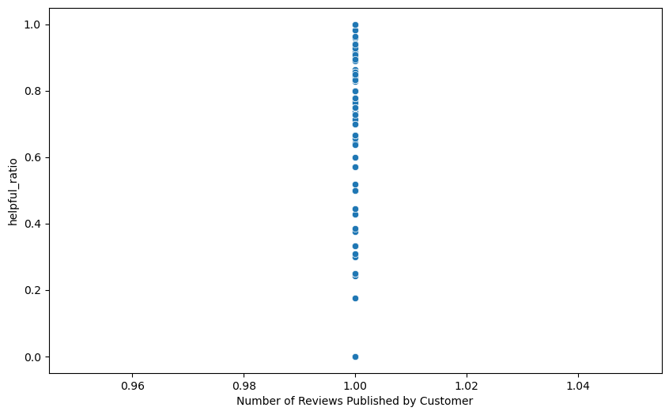

```python
plt.figure(figsize=(10, 6))
sns.scatterplot(x='num_reviews', y='helpful_ratio', data=customer_id_helpful)
plt.xlabel('Number of Reviews Published by Customer')
```

## no correlation exists between no. of reviews published by a customer and the helpfulness ratio

```python
## using the calcs
correlation = customer_data['num_reviews'].corr(customer_data['avg_helpfulness_ratio'])
print(f"\nCorrelation between number of reviews and average helpfulness ratio: {correlation:.2f}")
```

[output not shown]

# highest correlation of all 3 above exists between review body length and helpfulness ratio, and that is very weak at 0.16

## emptying the dir and exporting the results. used gpt for all of below

```python
output_prefix = 'hhaq'
dir_out = 'temp'
output_path = f"gs://{bucket_write}/{output_prefix}/{dir_out}"
```

```python
# Delete the existing directory if it exists
from google.cloud import storage
client = storage.Client()
bucket = client.bucket(bucket_write)
blobs = bucket.list_blobs(prefix=f"{output_prefix}/{dir_out}")
for blob in blobs:
    blob.delete()
```

```python
mapped_rdd.saveAsTextFile(output_path)
```

```python
## nothing cached so not using unpersist()
```